# Instability as a Data Quality Issue in Wikipedia

*Example of Women-Related Topics*

Author

Anju Yamada

Published

01.04.2026

Modified

23.04.2026

Keywords

Wikipedia, data quality, instability, gender, edit conflict, burstiness

## 1 Introduction

Wikipedia is one of the most widely used knowledge infrastructures in the world. However, its content is not fixed. It is continuously updated, revised, and contested by editors. This dynamic character makes Wikipedia not only a source of information, but also a data system shaped by ongoing social processes. Early work comparing Wikipedia with traditional encyclopedias has shown that its accuracy can be comparable in many cases, while still varying across articles and topics (Giles 2005).

Prior research has examined the quality and reliability of Wikipedia articles, emphasizing the implications of its open and collaborative nature. Because Wikipedia allows a large number of contributors to continuously edit and revise content, article quality is inherently dynamic and subject to variation over time (Moás and Lopes 2024). In addition to textual characteristics, revision history and editing behavior have been identified as important indicators for evaluating article quality, reflecting the process through which content is produced and maintained (Raman et al. 2020; Zeng et al. 2006).

At the same time, editing activity in Wikipedia is shaped by social interaction and conflict. Previous studies have shown that intense disagreements, often manifested as mutual reverts, characterize a subset of highly contested articles (Sumi and Yasseri 2011). These findings suggest that certain topics may exhibit higher levels of revert-related instability, reflecting ongoing editorial contestation.

In parallel, research on human dynamics demonstrates that activity is often temporally concentrated rather than evenly distributed. Human activity patterns have been shown to follow bursty dynamics, where short periods of intense activity are followed by longer periods of inactivity (Barabasi 2005). Editing behavior in Wikipedia exhibits similar bursty patterns, where periods of intense activity are followed by relative inactivity (Choi, Hiraoka, and Jo 2021). Such burstiness may reflect external attention, coordinated interaction, or event-driven editing processes, indicating that instability can also emerge through temporal concentration rather than explicit conflict.

Furthermore, prior work has identified systematic biases in Wikipedia content, particularly in relation to gender and diversity. Studies show that women are underrepresented and differently characterized in Wikipedia articles (Reagle and Rhue 2011; Graells-Garrido, Lalmas, and Menczer 2015; Sun and Peng 2021). These findings suggest that women-related topics might be shaped by distinct social and editorial dynamics, including uneven attention and potentially heightened contestation.

Despite these advances, existing research has primarily focused on content-based quality measures or revision-based indicators such as edit counts and revert rates. Less attention has been given to the temporal stability of articles as a dimension of data quality. In particular, it remains unclear whether certain types of pages—such as women-related biography pages—are systematically more unstable, and whether such instability affects their reliability as data.

From a data quality perspective, different forms of instability may correspond to different types of measurement-related uncertainty in the data generation process. For example, bursty editing dynamics can be interpreted as structural instability, where editing activity is highly concentrated in a small number of days. Temporal instability captures how often such intense editing days occur within a page. Revert-related activity, in turn, reflects observable disagreement and correction processes among editors.

These patterns suggest that instability in Wikipedia is not a single phenomenon, but a multidimensional one, arising from different mechanisms that introduce different types of uncertainty into the data.

Applied to digital behavioral data such as Wikipedia, instability in editing activity can be understood as a form of measurement-related distortion. Temporal concentration of edits, for example, may influence how content is represented at specific points in time, even without explicit disagreement among editors. This perspective suggests that instability is not merely a descriptive feature of collaborative systems, but a relevant dimension of data quality that should be explicitly analyzed.

This study addresses this gap by conceptualizing instability as a data quality issue. Rather than focusing only on the volume of edits or the presence of conflict, it examines how editing activity is distributed over time. Specifically, it investigates whether women-related biography pages differ from other pages in terms of structural instability, temporal instability, and revert-related instability.

English Wikipedia is used as the empirical setting because it is the largest and most extensively studied language edition, providing a rich and well-documented dataset for analyzing editing behavior and data quality (Moás and Lopes 2024; Raman et al. 2020).

This study adopts an asymmetric comparison between women-related pages and all other pages. Gender-related topics are expected to attract uneven, event-driven attention, resulting in bursty patterns of editing activity rather than steady updates.

The focus on women-related content is motivated by prior research documenting systematic differences in representation and editorial dynamics for women in Wikipedia. Rather than comparing all gender categories symmetrically, the aim is to test whether women-related pages deviate from the broader baseline of Wikipedia content in terms of instability.

**Research Questions**

- **RQ1**: Are women-related Wikipedia pages more unstable than other pages?
- **RQ2**: Does instability arise primarily from temporal concentration or revert-related conflict?
- **RQ3**: Can instability be mitigated, and how?

**Hypotheses**

- **H1 (structural instability; RQ1 & RQ2):**  
  Women-related biography pages exhibit higher structural burstiness (edit concentration).
- **H2 (temporal instability; RQ1 & RQ2):**  
  Women-related biography pages are expected to show higher burst-day rates.
- **H3 (revert-related instability; RQ1 & RQ2):**  
  Women-related biography pages exhibit higher revert-related instability.

## 2 Data and Research Design

This report uses Wikimedia data for English Wikipedia, combining page-level metadata, daily pageviews, and edit logs. Women-related pages were operationalized using the label `Culture.Biography.Women`(probability > 0.20).. Biography pages are also identified using `Culture.Biography.Biography*`.

Our analysis distinguishes between three related dimensions of instability:

1. **Structural instability** at the page level  
   This captures whether editing activity is concentrated into a small number of days for a page overall.
2. **Temporal instability** at the day level  
   This captures whether a specific page-day is unusually intense relative to that page’s normal editing pattern.
3. **Revert-related instability**  
   This captures the extent to which edits are undone, reflecting disagreement and conflict in editorial activity.

This report interprets all three as potential data quality issues, especially in relation to consistency and reliability.

## 3 Structural Instability at the Page Level

This report first examines structural instability at the page level. Here, instability is defined as the concentration of edits within a small number of days. This captures whether some pages are structurally more burst-prone than others. Table 1 reports descriptive statistics of page-level instability by topic group.

Table 1: Page-level instability by topic group

Page-level instability by topic group

| women_related_page | n_pages | mean_edit_burst | median_edit_burst | mean_burst_day_rate | mean_reverted_edit_share | mean_n_edits | mean_n_active_days |
| --- | --- | --- | --- | --- | --- | --- | --- |
| FALSE | 3078 | 0.44 | 0.333 | 0.017 | 0.179 | 5.860 | 5.067 |
| TRUE | 441 | 0.58 | 0.500 | 0.008 | 0.172 | 3.415 | 3.159 |

Women-related page shows a higher mean edit burst (0.58) than other pages (0.44), indicating stronger concentration of edits. In Figure 1, the horizontal line inside each box marks the median, while the white dot indicates the mean, so the figure visualizes the full distribution rather than the mean alone.

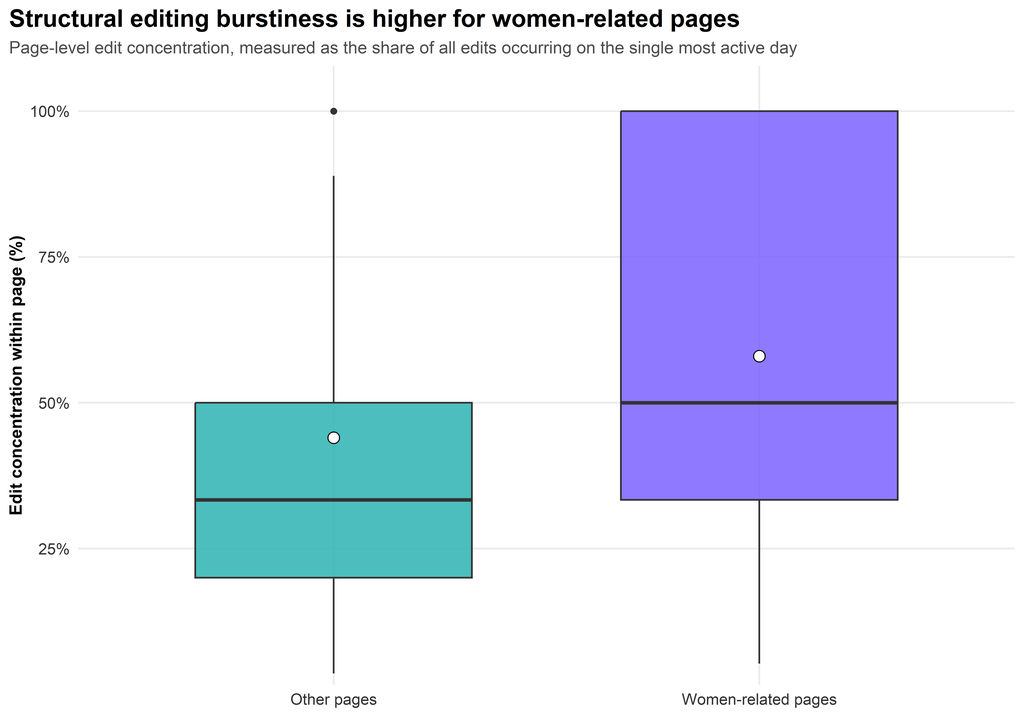

Figure 1: Structural editing burstiness by topic

women-related pages show substantially higher structural burstiness than other pages, not only in terms of the mean but across the entire distribution. As shown in Figure 1, the median edit concentration is also higher for women-related pages, indicating that the difference is not driven solely by a small number of extreme cases. In addition, the distribution for women-related pages is more spread out and places more mass in the upper range, with many pages exhibiting very high levels of concentration. This suggests that a larger share of women-related pages experience periods where a substantial proportion of edits are concentrated in a single day.

By contrast, non-women pages are more concentrated in the lower range of the distribution, indicating more evenly distributed editing activity across time.

Taken together, these patterns indicate that the higher mean burstiness observed for women-related pages reflects a systematic shift in the distribution, rather than being driven by a small number of outliers.

A Welch two-sample t-test shows that women-related pages exhibit significantly higher structural burstiness ($t = -8.41$, $df = 552.99$, $p < .001$). The mean burstiness is 0.580 for women-related pages and 0.440 for non-women pages.

This indicates that women-related pages show stronger temporal concentration of editing activity at the page level. **Thus, H1 is strongly supported.**

## 4 Temporal Instability in Burst-Day Rates

This report next examines instability at the page-day level. This section examines temporal instability using each page’s burst-day rate, defined as the share of active days on that page that are classified as burst days. This keeps the burst-day analysis comparable at the page level while preserving the page-relative definition of a burst event. Table 2 reports page-level summaries of this burst-day rate by topic group.

Table 2: Page-level burst-day rates by topic group

Page-level burst-day rates by topic group

| women_related_page | n_pages | mean_burst_day_rate | median_burst_day_rate | mean_edits_day | mean_editors_day | mean_reverted_edit_share |
| --- | --- | --- | --- | --- | --- | --- |
| FALSE | 3078 | 0.017 | 0 | 1.084 | 1.054 | 0.179 |
| TRUE | 441 | 0.008 | 0 | 1.056 | 1.033 | 0.172 |

The share of burst days is lower for women-related pages (0.8%) than for other pages (1.7%), suggesting that burst events are not more frequent in women-related topics.

Figure 2 compares the mean page-level burst-day rate by topic group.

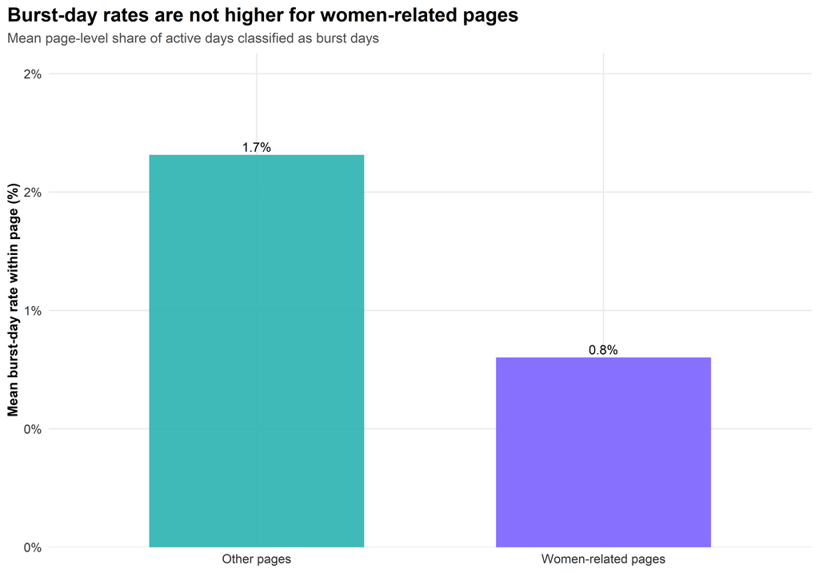

Figure 2: Page-level burst-day rates by topic

Contrary to expectations, women-related pages exhibit a lower burst-day rate (0.8%) than other pages (1.7%).

This indicates that women-related pages are not characterized by more frequent burst events. Instead, burst days are relatively less common within these pages.

Combined with the results from Figure 1, this suggests that the higher structural burstiness observed in women-related pages does not arise from more frequent bursts, but rather from a stronger concentration of edits into a smaller number of days when bursts do occur. In other words, burst events are less frequent but more impactful in women-related pages.

A Welch two-sample t-test comparing page-level burst-day rates shows that women-related pages do not have higher burst-day rates than other pages. Instead, non-women pages have a higher average share of active days classified as burst days. This means that women-related pages are not characterized by more frequent burst events at the day level, even though they remain more structurally bursty overall. **Thus, H2 is not supported.**

## 5 Revert-related Instability

This section examines whether women-related pages show higher levels of revert-related instability. Here, instability is defined as the extent to which edits are reverted, reflecting disagreement and conflict in editorial activity.

Figure 3 compares the mean page-level share of reverted edits across topic groups.

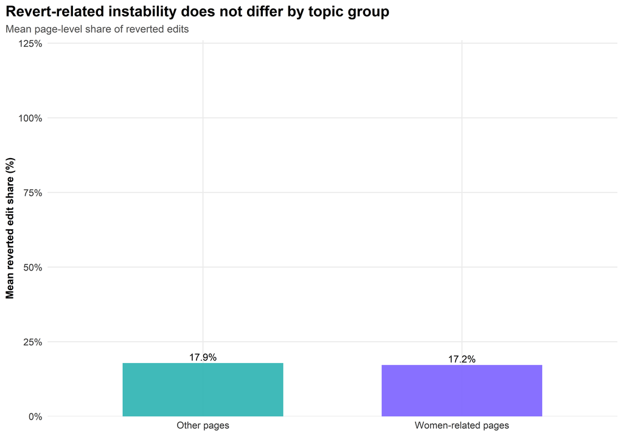

Figure 3: Revert-related instability by topic

This indicates that women-related pages are not characterized by higher levels of editorial conflict, as measured by the proportion of edits that are undone. In other words, disagreement and direct contestation do not appear to be more prevalent in these pages.

Taken together with the results from Figures 1 and 2, this finding suggests that the instability observed in women-related pages is not driven by conflict-based mechanisms such as reverts. Instead, it is more consistent with temporal concentration dynamics, where edits are clustered into specific periods without necessarily involving higher levels of disagreement.

This indicates that women-related pages are not more revert-prone than other pages. **Thus, H3 is not supported.**

## 6 Mitigation Strategies

This study focuses on mitigating **structural instability**, as this is the primary dimension along which women-related pages differ from other pages. Because no systematic differences are observed in revert-related instability, mitigation efforts are directed toward reducing the concentration of edits over time.

The following burst-focused strategies are evaluated:

- burst weighting
- event-day trimming
- combined mitigation (event-day trimming + burst weighting)

Table 3 compares instability measures across mitigation strategies.

Table 3: Structural instability across mitigation designs

Structural instability across mitigation designs

| women_related_page | design | mean_edit_burst | mean_n_edits |
| --- | --- | --- | --- |
| FALSE | raw | 0.440 | 5.860 |
| TRUE | raw | 0.580 | 3.415 |
| FALSE | topic_burst_weighted | 0.384 | 6.641 |
| TRUE | topic_burst_weighted | 0.513 | 3.965 |
| FALSE | event_day_trimmed | 0.429 | 5.330 |
| TRUE | event_day_trimmed | 0.574 | 3.256 |
| FALSE | combined | 0.370 | 6.101 |
| TRUE | combined | 0.504 | 3.796 |

Burst-focused weighting and event-day trimming are evaluated because they directly target the concentration of edits over time. Compared with the raw design, these approaches reduce page-level structural instability more directly. Because all mitigation designs are summarized at the page level, these comparisons are directly comparable across strategies.

Figure 4 compares structural instability across mitigation strategies.

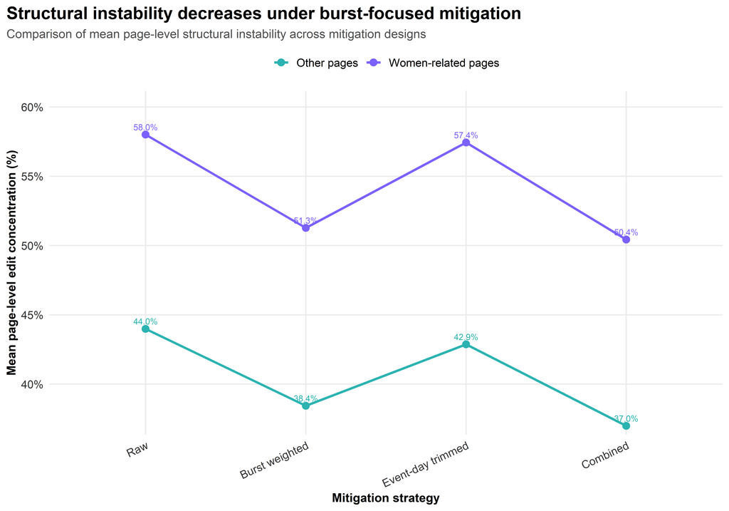

Figure 4: Mitigation comparison: structural instability

Importantly, the reduction is observed across both topic groups, indicating that structural instability is not confined to a specific subset of pages but reflects a broader feature of editing dynamics.

At the same time, the relative difference between women-related and other pages remains visible under burst weighting, event-day trimming, and the combined design.

In other words, the higher level of structural burstiness in women-related pages does not appear to be driven solely by a small number of extreme observations. Instead, it reflects a more general pattern in how editing activity is distributed over time within these pages.

## 7 Discussion and Conclusion

This study examined whether women-related Wikipedia pages are more unstable than other pages, and whether that instability can be understood as a data quality issue.

The results provide **dimension-specific evidence**.

First, women-related pages are significantly more bursty at the page level. **H1 is strongly supported.** This indicates that editing activity is more temporally concentrated for these pages, suggesting a form of structural, topic-related instability.

Second, the burst-day analysis **does not support H2.** Women-related pages do not show a higher page-level burst-day rate, meaning that a larger share of their active days is not classified as burst days under the current page-relative definition. Their higher instability therefore appears to stem more from overall concentration of edits into a few days than from more frequent burst days.

Third, we do not find evidence that women-related pages have a higher reverted edit share. **H3 is therefore not supported.** This suggests that instability in these pages is not primarily driven by overt revert conflict.

### 7.1 Dimensions of Instability

Taken together, these findings suggest that instability in Wikipedia has three distinct dimensions:

- **Structural instability**  
  reflected in the concentration of edits across time
- **Temporal instability**  
  reflected in the frequency of burst days within a page
- **Revert-related instability**  
  capturing editorial conflict, reflected in the share of reverted edits

These dimensions are related but empirically distinct. Women-related pages appear especially prone to structural instability, but not to higher levels of temporal or revert-related instability.

### 7.2 Mitigation Implications

The mitigation analysis focuses on structural instability, which is the primary source of instability observed in women-related pages. Burst-focused strategies effectively reduce edit concentration. Revert-related instability is not targeted because it does not differ systematically between topic groups.

### 7.3 Summary of Findings

The hypotheses (H1–H3) jointly address RQ1 and RQ2 by capturing different dimensions of instability, while RQ3 is examined through a mitigation analysis.

Overall, these findings show that instability in women-related pages is best understood as a form of temporal concentration rather than conflict-driven volatility, and that mitigation strategies can reduce but not fully eliminate this pattern.

### 7.4 Implications for Data Quality

From a measurement perspective, the forms of instability identified in this study represent sources of uncertainty in the observed values of Wikipedia content over time. Instability is therefore not merely platform noise, but a data quality issue that affects how reliably observed page states reflect underlying content.

Structural instability is particularly important, as concentrated editing episodes can distort the observed state of a page at a given moment. Pages captured during such periods may not reflect stable underlying content.

Temporal and revert-related instability capture different forms of measurement-related uncertainty: the former reflects irregular editing patterns over time, while the latter reflects observable disagreement and correction processes. These do not imply that the data are incorrect, but that observed values may deviate from a more stable underlying state.

Overall, instability introduces structured measurement-related uncertainty into Wikipedia data, with important implications for the reliability of downstream analyses.

### 7.5 Future Research

Future research could extend this analysis by comparing results between men- and women-related pages, as well as across different types of topics.

## 8 References

Barabasi, Albert-Laszlo. 2005. “The Origin of Bursts and Heavy Tails in Human Dynamics.” *Nature* 435 (7039): 207–11. https://idp.nature.com/authorize/casa?redirect_uri=https://www.nature.com/articles/nature03459&casa_token=YKjOMredjuEAAAAA:y-ur4yCleY5OivhhSxIvgSwxNVVxjlFP8tdLnJRE7ONRybpNqw6_315pR9E2xdYatfe55X9Ha7CxxJc2bg.

Choi, Jeehye, Takayuki Hiraoka, and Hang-Hyun Jo. 2021. “Individual-Driven Versus Interaction-Driven Burstiness in Human Dynamics: The Case of Wikipedia Edit History.” *Physical Review E* 104 (1): 014312. https://doi.org/10.1103/PhysRevE.104.014312.

Giles, Jim. 2005. “Special Report Internet Encyclopaedias Go Head to Head.” *Nature* 438 (15): 900–901. https://www.aetherometry.com/Electronic_Publications/Politics_of_Science/Antiwikipedia2/Appendix_1.html.

Graells-Garrido, Eduardo, Mounia Lalmas, and Filippo Menczer. 2015. “First Women, Second Sex: Gender Bias in Wikipedia.” In *Proceedings of the 26th ACM Conference on Hypertext & Social Media - HT ’15*, 165–74. Guzelyurt, Northern Cyprus: ACM Press. https://doi.org/10.1145/2700171.2791036.

Moás, Pedro Miguel, and Carla Teixeira Lopes. 2024. “Automatic Quality Assessment of Wikipedia Articles—A Systematic Literature Review.” *ACM Computing Surveys* 56 (4): 1–37. https://doi.org/10.1145/3625286.

Raman, Narun, Nathaniel Sauerberg, Jonah Fisher, and Sneha Narayan. 2020. “Classifying Wikipedia Article Quality With Revision History Networks.” In *Proceedings of the 16th International Symposium on Open Collaboration*, 1–7. Virtual conference Spain: ACM. https://doi.org/10.1145/3412569.3412581.

Reagle, Joseph, and Lauren Rhue. 2011. “Gender Bias in Wikipedia and Britannica.” *International Journal of Communication* 5: 21–21. https://ijoc.org/index.php/ijoc/article/view/777.

Sumi, Róbert, and Taha Yasseri. 2011. “Edit Wars in Wikipedia.” In *2011 IEEE Third International Conference on Privacy, Security, Risk and Trust and 2011 IEEE Third International Conference on Social Computing*, 724–27. IEEE. https://ieeexplore.ieee.org/abstract/document/6113205/.

Sun, Jiao, and Nanyun Peng. 2021. “Men Are Elected, Women Are Married: Events Gender Bias on Wikipedia.” In *Proceedings of the 59th Annual Meeting of the Association for Computational Linguistics and the 11th International Joint Conference on Natural Language Processing (Volume 2: Short Papers)*, 350–60. https://aclanthology.org/2021.acl-short.45/.

Zeng, Honglei, Maher Alhossaini, Li Ding, Richard Fikes, and Deborah L. McGuinness. 2006. “Computing Trust from Revision History.” In *Proceedings of the 2006 International Conference on Privacy, Security and Trust*. https://ebiquity.umbc.edu/paper/html/id/320/Computing-Trust-from-Revision-History%7D.